# Analysis on Ford-GoBike Systems

## Investigation Overview

### In this investigation, I wanted to look at the characteristics of these users to know the type that takes longer trips and when. I focused on the user_type, the member_age, hour_of_day and day_of_week.

## Dataset Overview

### This data set contains information of over 170000 rides taken from one station to another in San Francisco Bay area, with over 4000 bikes used. The attributes included duration (in seconds), user_type, start_time, end time, as well as additional information such as bike_id, start_station (id, name, longitude and latitude),end station (id, name, longitude and latitude), member_birth_year, and member_gender. Rows with missing values were dropped and 3 features were created (hour_of_day, day_of_week and member_age) from start_time and member_birth_yea`.

```python
# import all packages and set plots to be embedded inline
import numpy as np
import pandas as pd
import matplotlib.pyplot as plt
import seaborn as sns
import plotly.express as px
import calendar

%matplotlib inline

# suppress warnings from final output
import warnings
warnings.simplefilter("ignore")
```

```python
# load in the dataset into a pandas dataframe
gobike_df = pd.read_csv('201902-fordgobike-tripdata.csv')

# drop missing vallues
gobike_df = gobike_df.dropna()
```

```python
# convert features to datetime dtype
gobike_df['start_time']=pd.to_datetime(gobike_df['start_time'])
gobike_df['end_time']=pd.to_datetime(gobike_df['end_time'])

gobike_df['hour_of_day'] = gobike_df.start_time.dt.hour.astype(int)
gobike_df['day_of_week'] = gobike_df.start_time.dt.strftime('%a')
#gobike_df['month_of_year'] = pd.DatetimeIndex(gobike_df['start_time']).month
#gobike_df['month_of_year'] = gobike_df['month_of_year'].astype(int).apply(lambda x: calendar.month_abbr[x])
gobike_df['member_age'] = 2022-gobike_df['member_birth_year'].astype(int)
```

## The distribution of trip duration and member age

### The duration in the dataset take on a very large range of values, from 60 seconds at the lowest to 84548 seconds at the highest for duration. The member_age from 21 years to 144 years for age. After removing outliers from both features and plotted on a logarithmic scale, the distribution of bike ride duration look more like normal distribution with peak at little less than 550 seconds.

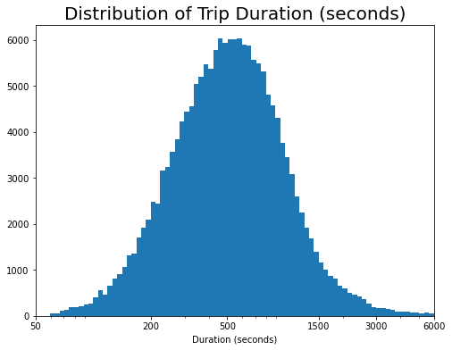

```python
log_binsize=0.025
bin_edges=10**np.arange(0,
np.log10(gobike_df.duration_sec.max())+log_binsize, log_binsize)
plt.figure(figsize=[8,6])
plt.hist(data=gobike_df, x='duration_sec', bins=bin_edges)
plt.xscale('log')
plt.xticks([50, 200, 500, 1500, 3000, 6000],
[50, 200, 500, 1500, 3000, 6000])
plt.xlabel('Duration (seconds)')
plt.xlim([50,6000])
plt.title('Distribution of Trip Duration (seconds)', fontsize=20)
plt.show()
```

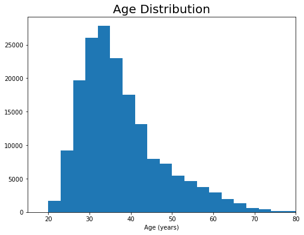

```python
binsize=3
bin_edges=np.arange(20, gobike_df.member_age.max()+binsize, binsize)
plt.figure(figsize=[8,6])
plt.hist(data=gobike_df, x='member_age', bins=bin_edges)
plt.xlabel('Age (years)')
plt.xlim([15,80])
plt.title('Age Distribution', fontsize=20)
plt.show()
```

## Proportion of user types on all bike trips taken

### Majority of the bike users are Subscribers (90.7%) and Customers (for those who do not subscribe) were 9.3%.

```python
#filtering the values less than 6000 in `duration_sec` and less than 80 in `member_age`
outliers=((gobike_df.duration_sec>6000)|(gobike_df.member_age>80))
outlier_proportion = (outliers.sum()/gobike_df.shape[0])*100

gobike_df=gobike_df[-outliers]
```

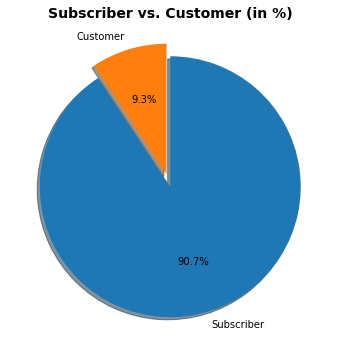

```python
# Plot bar chart in %
plt.figure(figsize=[8,6])
explode = (0, 0.1)
sorted_counts = gobike_df['user_type'].value_counts()
plt.pie(sorted_counts, explode=explode, labels = sorted_counts.index,
        autopct='%1.1f%%',shadow=True, startangle = 90,counterclock = False)
plt.title('Subscriber vs. Customer (in %)', fontsize=14, fontweight='bold');
```

## Bikes rides vs time_of_day and day _of_week

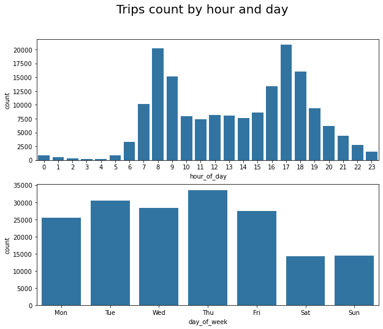

```python
# plotting hour of the day and day of the week together
fig, ax=plt.subplots(nrows=2, figsize=[10,8])
default_color=sns.color_palette()[0]
sns.countplot(data=gobike_df, x='hour_of_day', color=default_color, ax=ax[0])
order = ['Mon', 'Tue', 'Wed', 'Thu', 'Fri', 'Sat', 'Sun']
sns.countplot(data=gobike_df, x='day_of_week', color=default_color, ax=ax[1], order=order)

fig.suptitle('Trips count by hour and day', fontsize=20)
plt.show()
```

## Relationship between duration and age with the the days of the week.

### Bike rides on weekends (Sat-Sun) have longer trip durations as compared to bike rides on other weekdays (Mon-Fri) and on average, users who are ‘Customer’ have longer bike trip durations ascompared to users who are ‘Subscriber’. Also, Bikers on weekdays (Mon-Fri) tend to be older than bikers on weekends(Sat-Sun).

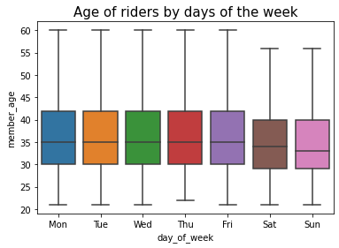

```python
sns.boxplot(data=gobike_df, x="day_of_week", y="member_age", showfliers=False, order=order);
plt.title('Age of riders by days of the week', fontsize=15);
```

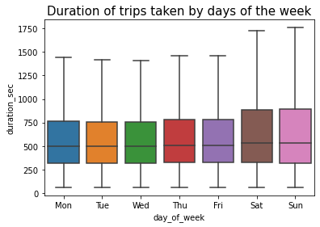

```python
sns.boxplot(data=gobike_df, x="day_of_week", y="duration_sec", showfliers=False, order=order);
plt.title('Duration of trips taken by days of the week', fontsize=15);
```

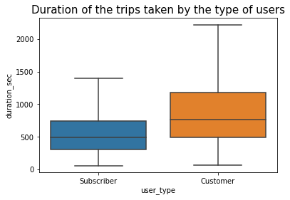

```python
sns.boxplot(data=gobike_df, x="user_type", y="duration_sec", showfliers=False);
plt.title('Duration of the trips taken by the type of users', fontsize=15);
```

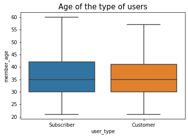

```python
sns.boxplot(data=gobike_df, x="user_type", y="member_age", showfliers=False);
plt.title('Age of the type of users', fontsize=15);
```

### Female bikers mostly like to take their trip around the city of San Jose in California. Unknown gender ride to and fro, between San Francisco and Oakland. Also, from the map below, the male gender seemed to be overshadowed by the female and other gender in both San Francisco and San Jose. Although the male are the most bike riders, it could be that these male riders have a very special location in San Francisco and San Jose where they ride their bikes.

```python
#plotting a mapbox for non-deviants and positive-deviants in domain 4
fig = px.scatter_mapbox(gobike_df, lat='start_station_latitude', lon='start_station_longitude',
                        width=800, zoom=4, color='member_gender',
                        height=600, hover_data=['user_type'],
                       )
fig.update_layout(mapbox_style='open-street-map')

fig.show()
```

[interactive chart not shown]

```python
!jupyter nbconvert FORD_GOBIKE_EXPLANATORY_ANALYSIS.ipynb --to slides --post serve --no-input --no-prompt
```

[output not shown]